# Retail Store Assignment

PARAS BHATTARAI

06/01/2021

# BUSINESS PROBLEM:

#### A Retail store is required to analyze the day-to-day transactions and keep a

#### track of its customers spread across various locations along with their

#### purchases/returns across various categories.

#### Create an RMarkdown report and display the below calculated metrics,

### DATA AVAILABLE -

#### Customer: Customers information including demographics

#### Transaction: Transactions of customers

#### Product Hierarchy: Product information (category, sub category etc…)

#### 1. Merge the datasets Customers, Product Hierarchy and Transactions as

#### Customer_Final. Ensure to keep all customers who have done

#### transactions with us and select the join type accordingly.

#### a. Use the base merge()

```r
Customer = read.csv("Customer.csv")
prod_cat = read.csv("prod_cat_info.csv")
Transactions =read.csv("Transactions.csv")
```

##### Common column that can be used to perform the join is customer_Id in Customer table and cust_id in Transactions table and prod_cat table can be combined using prod_cat_code and prod_sub_cat_code from prod_cat table. (Inner JOIN is Used here as i only want common records.)

```r
PREDATA <-merge(x=Customer, y=Transactions, by.x ="customer_Id", by.y ="cust_id", all = FALSE)

Customer_Final <- merge(x= PREDATA, y = prod_cat, by.x = c("prod_cat_code", "prod_subcat_code"),
                        by.y = c("prod_cat_code","prod_sub_cat_code"), all = FALSE)
```

##### Checking NA Value In The Dataset

```r
sum(is.na(Customer_Final))
```

```
## [1] 8
```

##### Droping NA Value as Number of NA Value is very less

```r
require(tidyr)
Customer_Final <- tidyr::drop_na(Customer_Final)
```

#### b. Dplyr merge functions

```r
require(dplyr)
DATA <- dplyr::inner_join(Customer,Transactions, by =c("customer_Id" = "cust_id"))

DATAFINAL <- dplyr::inner_join(DATA,prod_cat, by =c("prod_cat_code" = "prod_cat_code",
                                                    "prod_subcat_code" = "prod_sub_cat_code" ))
```

#### 2. Prepare a summary report for the merged data set.

#### a. Get the column names and their corresponding data types

```r
str(Customer_Final)
```

```
## 'data.frame':    23045 obs. of  15 variables:
##  $ prod_cat_code   : int  1 1 1 1 1 1 1 1 1 1 ...
##  $ prod_subcat_code: int  1 1 1 1 1 1 1 1 1 1 ...
##  $ customer_Id     : int  274066 268597 274484 268701 267134 268161 274260 274926 268126 274618 ...
##  $ DOB             : chr  "26-10-1976" "01-05-1986" "13-11-1976" "22-02-1978" ...
##  $ Gender          : chr  "M" "F" "F" "M" ...
##  $ city_code       : int  8 10 9 5 2 4 3 2 2 7 ...
##  $ transaction_id  : num  3.81e+10 7.69e+10 1.88e+10 1.06e+10 9.78e+10 ...
##  $ tran_date       : chr  "5/3/2013" "19-01-2013" "20-08-2011" "30-01-2012" ...
##  $ Qty             : int  5 4 2 5 5 3 2 5 1 4 ...
##  $ Rate            : int  1239 853 324 1342 461 1309 630 224 1249 561 ...
##  $ Tax             : num  650 358 68 705 242 ...
##  $ total_amt       : num  6845 3770 716 7415 2547 ...
##  $ Store_type      : chr  "Flagship store" "MBR" "Flagship store" "MBR" ...
##  $ prod_cat        : chr  "Clothing" "Clothing" "Clothing" "Clothing" ...
##  $ prod_subcat     : chr  "Women" "Women" "Women" "Women" ...
```

#### b. Top/Bottom 10 observations

```r
head(Customer_Final,10)
```

```
##    prod_cat_code prod_subcat_code customer_Id        DOB Gender city_code
## 1              1                1      274066 26-10-1976      M         8
## 2              1                1      268597 01-05-1986      F        10
## 3              1                1      274484 13-11-1976      F         9
## 4              1                1      268701 22-02-1978      M         5
## 5              1                1      267134 14-09-1992      M         2
## 6              1                1      268161 25-06-1979      M         4
## 7              1                1      274260 10-11-1991      M         3
## 8              1                1      274926 20-10-1986      M         2
## 9              1                1      268126 12-09-1975      F         2
## 10             1                1      274618 09-12-1992      F         7
##    transaction_id  tran_date Qty Rate     Tax total_amt     Store_type prod_cat
## 1     38110368883   5/3/2013   5 1239 650.475  6845.475 Flagship store Clothing
## 2     76949751078 19-01-2013   4  853 358.260  3770.260            MBR Clothing
## 3     18838561375 20-08-2011   2  324  68.040   716.040 Flagship store Clothing
```

[output cut: 18 more lines]

```r
tail(Customer_Final,10)
```

```
##       prod_cat_code prod_subcat_code customer_Id        DOB Gender city_code
## 23036             6                2      274432 27-02-1984      F         2
## 23037             6                2      274884 29-03-1974      F         3
## 23038             6                2      272773 11-10-1989      M         8
## 23039             6                2      274869 16-02-1984      F         3
## 23040             6                2      270439 29-05-1982      F         2
## 23041             6                2      273465 24-10-1973      M         3
## 23042             6                2      274412 06-06-1971      F         4
## 23043             6                2      271227 17-09-1992      F         7
## 23044             6                2      274414 09-03-1983      F         3
## 23045             6                2      274625 28-07-1980      M         1
##       transaction_id  tran_date Qty Rate     Tax total_amt     Store_type
## 23036    96623093056 17-05-2012   3 1034 325.710  3427.710 Flagship store
## 23037    51656978003 14-09-2012   4  414 173.880  1829.880       TeleShop
## 23038    63342201990 20-11-2012   5  418 219.450  2309.450            MBR
```

[output cut: 18 more lines]

#### c. Create a Five-number summary for continuous variables (min, Q1, median,Q3 and max)

```r
summary(Customer_Final)
```

```
##  prod_cat_code   prod_subcat_code  customer_Id         DOB
##  Min.   :1.000   Min.   : 1.000   Min.   :266783   Length:23045
##  1st Qu.:2.000   1st Qu.: 3.000   1st Qu.:268936   Class :character
##  Median :4.000   Median : 5.000   Median :270981   Mode  :character
##  Mean   :3.764   Mean   : 6.149   Mean   :271023
##  3rd Qu.:5.000   3rd Qu.:10.000   3rd Qu.:273115
##  Max.   :6.000   Max.   :12.000   Max.   :275265
##     Gender            city_code      transaction_id       tran_date
##  Length:23045       Min.   : 1.000   Min.   :3.269e+06   Length:23045
##  Class :character   1st Qu.: 3.000   1st Qu.:2.492e+10   Class :character
##  Mode  :character   Median : 5.000   Median :5.009e+10   Mode  :character
##                     Mean   : 5.483   Mean   :5.007e+10
##                     3rd Qu.: 8.000   3rd Qu.:7.533e+10
##                     Max.   :10.000   Max.   :9.999e+10
##       Qty              Rate              Tax           total_amt
##  Min.   :-5.000   Min.   :-1499.0   Min.   :  7.35   Min.   :-8270.9
##  1st Qu.: 1.000   1st Qu.:  312.0   1st Qu.: 98.28   1st Qu.:  762.5
##  Median : 3.000   Median :  710.0   Median :199.08   Median : 1754.7
##  Mean   : 2.432   Mean   :  636.4   Mean   :248.69   Mean   : 2107.4
##  3rd Qu.: 4.000   3rd Qu.: 1109.0   3rd Qu.:365.71   3rd Qu.: 3569.2
##  Max.   : 5.000   Max.   : 1500.0   Max.   :787.50   Max.   : 8287.5
##   Store_type          prod_cat         prod_subcat
##  Length:23045       Length:23045       Length:23045
##  Class :character   Class :character   Class :character
##  Mode  :character   Mode  :character   Mode  :character
##
##
##
```

#### d. Frequency tables for all the categorical variables

##### Using Customerfinal Dataset for Analysis

```r
FREQ_STORETYPE <- Customer_Final %>% dplyr::group_by(Store_type) %>% dplyr::summarise(FREQ =
                                                                                        n()) %>% dplyr::arrange( desc(FREQ))
FREQ_STORETYPE
```

```
## # A tibble: 4 x 2
##   Store_type      FREQ
##   <chr>          <int>
## 1 e-Shop          9309
## 2 MBR             4661
## 3 Flagship store  4575
## 4 TeleShop        4500
```

```r
FREQ_PRODCAT <- Customer_Final %>% dplyr::group_by(prod_cat) %>% dplyr::summarise(FREQ =
                                                                                    n()) %>% dplyr::arrange( desc(FREQ))
FREQ_PRODCAT
```

```
## # A tibble: 6 x 2
##   prod_cat          FREQ
##   <chr>            <int>
## 1 Books             6068
## 2 Electronics       4894
## 3 Home and kitchen  4127
## 4 Footwear          2999
## 5 Clothing          2960
## 6 Bags              1997
```

```r
FREQ_PRODSUB <- Customer_Final %>% dplyr::group_by(prod_subcat) %>% dplyr::summarise(FREQ =
                                                                                       n()) %>% dplyr::arrange( desc(FREQ))
FREQ_PRODSUB
```

```
## # A tibble: 18 x 2
##    prod_subcat          FREQ
##    <chr>               <int>
##  1 Women                3048
##  2 Mens                 2911
##  3 Kids                 1997
##  4 Tools                1062
##  5 Fiction              1043
##  6 Kitchen              1037
##  7 Children             1035
##  8 Comics               1031
##  9 Mobiles              1031
## 10 Bath                 1022
## 11 Furnishing           1006
## 12 Non-Fiction          1003
## 13 DIY                   989
## 14 Cameras               984
## 15 Personal Appliances   972
## 16 Academic              967
## 17 Computers             956
## 18 Audio and video       951
```

#### 3. Generate histograms for all continuous variables and frequency bars for

#### categorical variables.

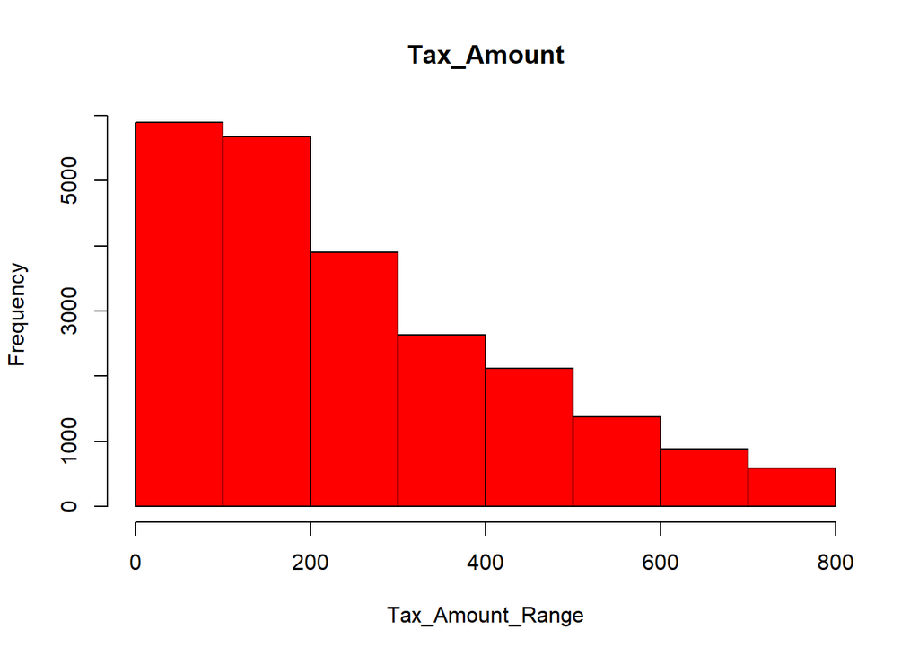

```r
hist(Customer_Final$Tax, breaks = 10, main = "Tax_Amount",col = "red", xlab = "Tax_Amount_Range", ylab = "Frequency")
```

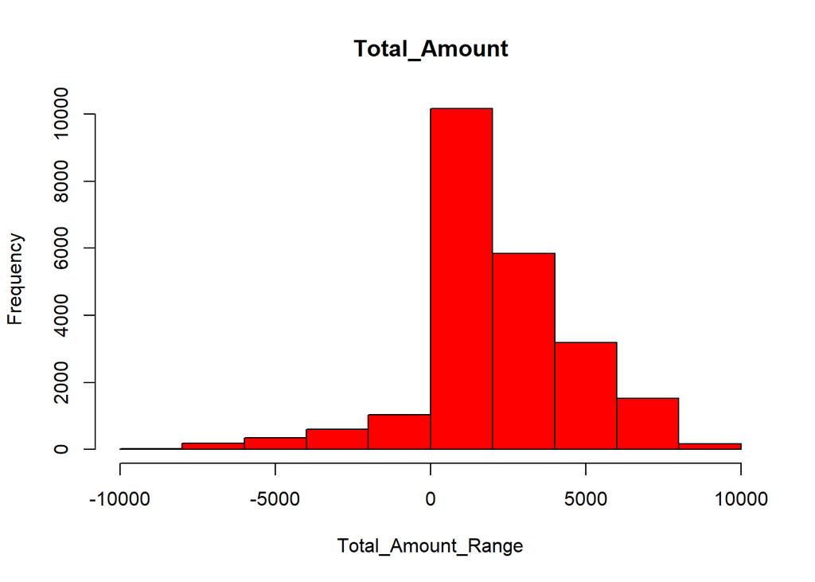

```r
hist(Customer_Final$total_amt, breaks = 10, main = "Total_Amount",col = "red", xlab = "Total_Amount_Range", ylab = "Frequency")
```

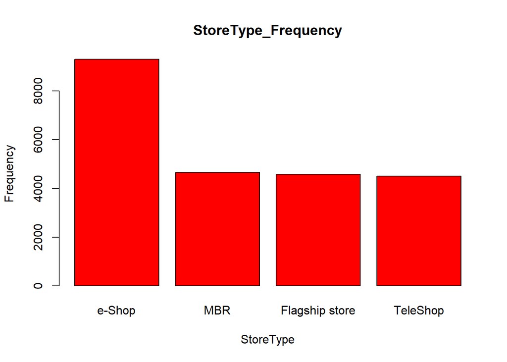

```r
barplot(FREQ_STORETYPE$FREQ, names.arg = FREQ_STORETYPE$Store_type, main = "StoreType_Frequency",col = "red", xlab = "StoreType", ylab = "Frequency"  )
```

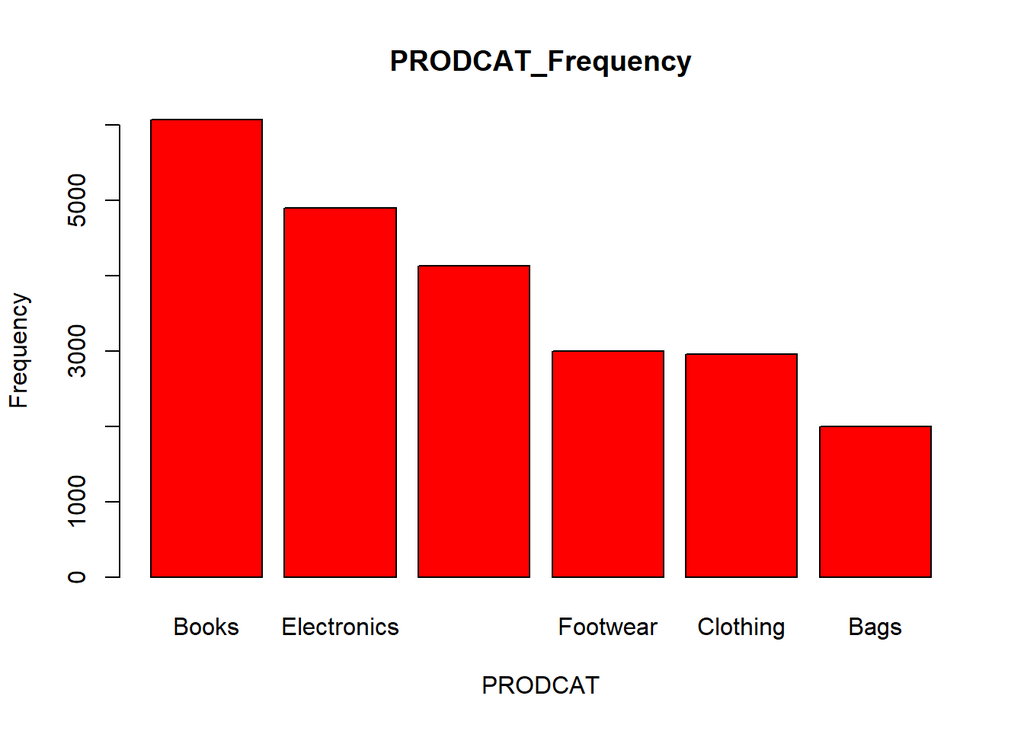

```r
barplot(FREQ_PRODCAT$FREQ, names.arg = FREQ_PRODCAT$prod_cat, main = "PRODCAT_Frequency", col = "red", xlab = "PRODCAT", ylab = "Frequency"  )
```

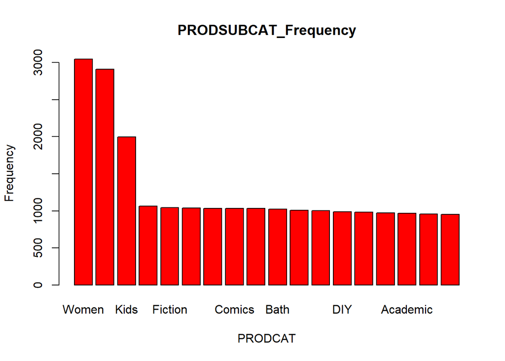

```r
barplot(FREQ_PRODSUB$FREQ, names.arg = FREQ_PRODSUB$prod_subcat, main = "PRODSUBCAT_Frequency", col = "red", xlab = "PRODCAT", ylab = "Frequency"  )
```

#### 4. Calculate the following information using the merged dataset :

#### a. Time period of the available transaction data

```r
require(lubridate)
Customer_Final$TRAN_DATE_FORMAT<- lubridate::dmy(Customer_Final$tran_date)

  A <- min(Customer_Final$TRAN_DATE_FORMAT)
  B <- max(Customer_Final$TRAN_DATE_FORMAT)


  (B-A)
```

```
## Time difference of 1130 days
```

#### b. Count of transactions where the total amount of transaction was negative

```r
Negative_transaction <- Customer_Final[(Customer_Final$total_amt < 0),]

length(Negative_transaction$transaction_id)
```

```
## [1] 2177
```

#### 5. Analyze which product categories are more popular among females vs male customers.

```r
Customer_FinalM <- Customer_Final[(Customer_Final$Gender =="M"),]
Popularity_columnM <- Customer_FinalM %>%  dplyr::group_by(Gender,prod_cat) %>% dplyr::summarise(Total_count =
                                                                                                   sum(Qty)) %>% dplyr::arrange( desc(Total_count))
Customer_FinalF <- Customer_Final[(Customer_Final$Gender =="F"),]
Popularity_columnF <- Customer_FinalF %>%  dplyr::group_by(Gender,prod_cat) %>% dplyr::summarise(Total_count =
                                                                                                   sum(Qty)) %>% dplyr::arrange( desc(Total_count))
Popularity_column <-cbind(Popularity_columnM,Popularity_columnF)
```

[output not shown]

```r
colnames(Popularity_column) <- c("GenderM","Prod_CategoryM", "Toal_CountM","GenderF","Prod_CategoryF", "Toal_CountF"  )
Popularity_column
```

```
## # A tibble: 6 x 6
##   GenderM Prod_CategoryM   Toal_CountM GenderF Prod_CategoryF   Toal_CountF
##   <chr>   <chr>                  <int> <chr>   <chr>                  <int>
## 1 M       Books                   7586 F       Books                   7070
## 2 M       Electronics             6470 F       Electronics             5827
## 3 M       Home and kitchen        5036 F       Home and kitchen        4895
## 4 M       Clothing                3748 F       Footwear                3716
## 5 M       Footwear                3555 F       Clothing                3425
## 6 M       Bags                    2345 F       Bags                    2362
```

#### 6. Which City code has the maximum customers and what was the percentage of customers from that city?

```r
Customer_City <- Customer_Final %>% dplyr::group_by(city_code) %>% dplyr::summarise(Total_Customer
                          = n(), Percentage =round(n()*100/length(Customer_Final$city_code),2)) %>% dplyr::arrange(desc(Percentage))
Customer_City
```

```
## # A tibble: 10 x 3
##    city_code Total_Customer Percentage
##        <int>          <int>      <dbl>
##  1         4           2422      10.5
##  2         3           2411      10.5
##  3         5           2360      10.2
##  4         7           2356      10.2
##  5        10           2333      10.1
##  6         8           2330      10.1
##  7         2           2270       9.85
##  8         1           2258       9.8
##  9         9           2178       9.45
## 10         6           2127       9.23
```

#### 7. Which store type sells the maximum products by value and by quantity?

```r
 Sell_By_value_And_Quantity <- Customer_Final %>% dplyr::group_by(Store_type) %>% dplyr::summarise(Quantity
                                                                     = sum(Qty), Revenue = sum(total_amt) )
Sell_By_value_And_Quantity
```

```
## # A tibble: 4 x 3
##   Store_type     Quantity   Revenue
##   <chr>             <int>     <dbl>
## 1 e-Shop            22759 19821407.
## 2 Flagship store    11131  9714802.
## 3 MBR               11194  9674486.
## 4 TeleShop          10972  9354208.
```

#### 8. What was the total amount earned from the “Electronics” and “Clothing” categories from Flagship Stores?

```r
FLAGSHIP_STORE <- Customer_Final[ Customer_Final$Store_type == "Flagship store",]

CATEGORY <- FLAGSHIP_STORE[(FLAGSHIP_STORE$prod_cat == "Clothing") |(FLAGSHIP_STORE$prod_cat == "Electronics"),  ]
CATEGORY_Elec_Clot <- CATEGORY %>% dplyr::group_by(prod_cat) %>% dplyr::summarise(Amount_Earned =
                                                                 sum(total_amt)) %>% dplyr::arrange(desc(Amount_Earned))
CATEGORY_Elec_Clot
```

```
## # A tibble: 2 x 2
##   prod_cat    Amount_Earned
##   <chr>               <dbl>
## 1 Electronics      2214513.
## 2 Clothing         1194423.
```

#### 9. What was the total amount earned from “Male” customers under the “Electronics” category?

```r
Customer_Male_Elec <- Customer_Final[ (Customer_Final$prod_cat == "Electronics") & (Customer_Final$Gender =="M"),]

Amount_Male_Elec <- Customer_Male_Elec  %>% dplyr::group_by(Gender,prod_cat) %>% summarise(Total_Amount = sum(total_amt))
Amount_Male_Elec
```

```
## # A tibble: 1 x 3
## # Groups:   Gender [1]
##   Gender prod_cat    Total_Amount
##   <chr>  <chr>              <dbl>
## 1 M      Electronics     5697630.
```

#### 10. How many customers have more than 10 unique transactions, after removing all transactions which have any negative amounts?

```r
Without_Negative <- Customer_Final[Customer_Final$total_amt >0 ,]

Transaction_Count <- Without_Negative %>% dplyr::group_by(customer_Id) %>% summarise(Total_Count = n())
Transaction_Count
```

```
## # A tibble: 5,504 x 2
##    customer_Id Total_Count
##          <int>       <int>
##  1      266783           4
##  2      266784           3
##  3      266785           7
##  4      266788           4
##  5      266794          11
##  6      266799           3
##  7      266803           1
##  8      266804           1
##  9      266805           1
## 10      266806           6
## # ... with 5,494 more rows
```

```r
GREATERTHAN10 <- Transaction_Count[Transaction_Count$Total_Count >10,]
length(GREATERTHAN10$customer_Id)
```

```
## [1] 6
```

#### 11. For all customers aged between 25 - 35, find out:

#### a. What was the total amount spent for for “Electronics” and “Books” product categories?

```r
DATE <- lubridate::dmy(Customer_Final$DOB)
TODAY_DATE <- Sys.Date()

Customer_Final$DIFFERENCE <- TODAY_DATE-DATE

AGE25_35_DATA <- Customer_Final[(Customer_Final$DIFFERENCE > 25*365.25) & (Customer_Final$DIFFERENCE < 35*365.25), ]

AGE25_35_ELCBOOK <- AGE25_35_DATA[ (AGE25_35_DATA$prod_cat == "Electronics") | (AGE25_35_DATA$prod_cat =="Books"),]

AGEBOOK_ELC <- AGE25_35_ELCBOOK %>% dplyr::group_by(prod_cat) %>% summarise(Total_Sum = sum(total_amt)) %>%dplyr::arrange(desc(prod_cat))
AGEBOOK_ELC
```

```
## # A tibble: 2 x 2
##   prod_cat    Total_Sum
##   <chr>           <dbl>
## 1 Electronics  3345118.
## 2 Books        3696677.
```

#### b. What was the total amount spent by these customers between 1st Jan, 2014 to 1st Mar, 2014?

```r
AGE25_35_DATA$New_tran_Date <- lubridate::dmy(AGE25_35_DATA$tran_date)

DATEBETWEEN_JANMARCH <- AGE25_35_DATA[(AGE25_35_DATA$New_tran_Date >= "2014-01-01") & (AGE25_35_DATA$New_tran_Date <= "2014-03-01"),]

AMOUNT_SPENT_BETWEEN <- DATEBETWEEN_JANMARCH  %>% dplyr::summarise(REVENUE = sum(total_amt))

AMOUNT_SPENT_BETWEEN
```

```
##    REVENUE
## 1 751183.4
```